# Универсальная_радуга_результата

### **Радуга результата**

Есть гипотеза, что количество решённых задач и качество решения(доля верных решённых заданий) должно хорошо коррелировать с конечным результатом ученика на экзамене.

Радуга результатов позволит непрерывно отслеживать успехи ученика.

В данном исследовании будут играть роль два параметра:

- Старательность: $log(∑m_i)$, где $m_i$ - это максимальное количество баллов которые можно получить за решение i-й задачи. Сумма производится по всем задачам, которые решал ученик
- Качество: $\sum_i \sum_j (a_{ij}/m_{i})$, где $a_{ij}$ - количество баллов, которые ученик получает за решение i-й задачи, под j-м номером КИМ.

**Результаты 9-ти классников**

Особенностью учеников 9-го класса является то, что их результаты являются дискретными. По осям откладывается логарифм старательности, а по оси игрек - качество

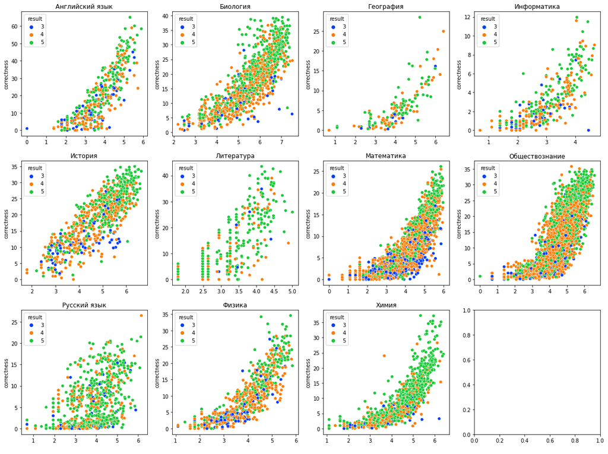

В таблице ниже можно видеть насколько высока корреляция между старательностью,качеством и конечным результатом. То есть например согласно этой модели в Английском языке старательность играет меньшую роль чем качество. Звучит странно, но тут нужно понимать, что качество и старательность в нашем случае - это чисто математические понятия.

|  | Предмет | Старательность | Качество | Комбинация |
| --- | --- | --- | --- | --- |
| 0 | Английский язык | 0.178084 | 0.262238 | 0.254029 |
| 1 | Биология | 0.241414 | 0.367714 | 0.356578 |
| 2 | География | 0.123302 | 0.178842 | 0.089877 |
| 3 | Информатика | 0.150095 | 0.246387 | 0.207732 |
| 4 | История | 0.278402 | 0.383130 | 0.396231 |
| 5 | Литература | 0.002765 | 0.093418 | 0.083706 |
| 6 | Математика | 0.196433 | 0.320936 | 0.314867 |
| 7 | Обществознание | 0.230443 | 0.299795 | 0.300940 |
| 8 | Русский язык | 0.084453 | 0.118107 | 0.090326 |
| 9 | Физика | 0.204084 | 0.322949 | 0.324450 |
| 10 | Химия | 0.253039 | 0.338946 | 0.274054 |

Далее мы построим графики с результатами но уже на фоне предполагаемой радуги результатов.

Графики будут представлены в двух видах.

- Сначала в урезанном виде, то есть только ту часть, которая имеет смысл
- Второй вариант - со всеми точками. То есть и теми, в которых ученики решили слишком мало заданий, чтобы помещать их на диаграмму. Чтобы видеть насколько много учеников не попали в рассмотрение я покажу то, что остаётся за кулисами.

Цветовое оформление радуги и шкала сбоку должны дать ученику понимание какой у него сейчас предполагаемый результат.

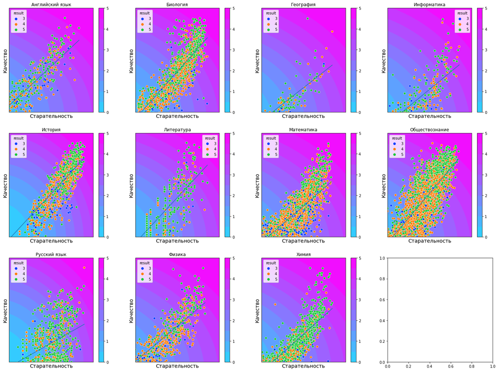

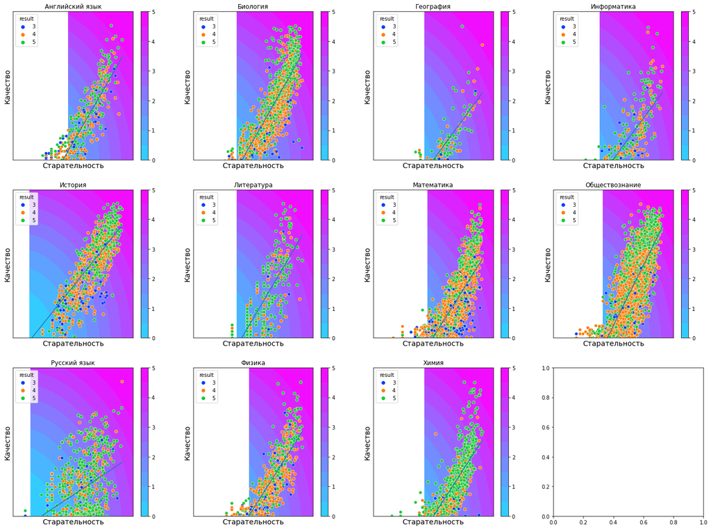

**Блок результатов ЕГЭ**

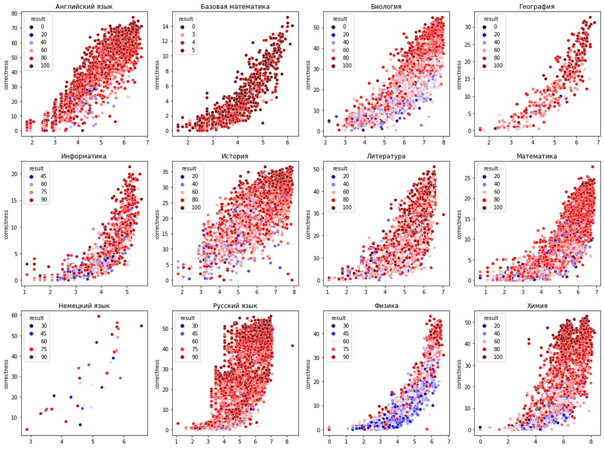

Аналогичная таблица с корреляциями

|  | Предмет | Старательность | Качество | Комбинация |
| --- | --- | --- | --- | --- |
| 0 | Английский язык | NaN | 0.425374 | NaN |
| 1 | Базовая математика | 0.164768 | 0.225801 | 0.189347 |
| 2 | Биология | 0.339269 | 0.519454 | 0.531739 |
| 3 | География | 0.452809 | 0.525784 | 0.520344 |
| 4 | Информатика | 0.274735 | 0.383391 | 0.350496 |
| 5 | История | 0.417586 | 0.533038 | 0.549438 |
| 6 | Литература | 0.228221 | 0.292163 | 0.290741 |
| 7 | Математика | 0.325627 | 0.421525 | 0.396802 |
| 8 | Немецкий язык | 0.107155 | 0.285680 | 0.322763 |
| 9 | Русский язык | 0.346125 | 0.426411 | 0.413231 |
| 10 | Физика | 0.347234 | 0.498900 | 0.500450 |
| 11 | Химия | 0.370141 | 0.587701 | 0.581847 |

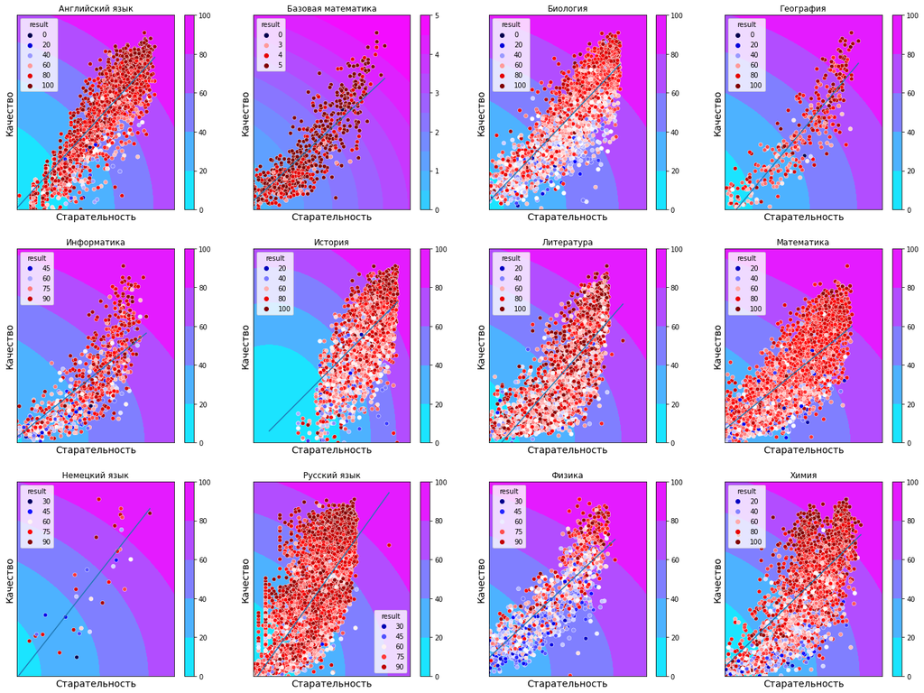

- Позже я построю траектории всех учеников. Сейчас это не получается сделать по некоторым причинам.
- Я попробую вывести траекторию "среднего ученика"
- Есть несколько идей для анализа. Например я достоверно выяснил, что ученики, которые начали заниматься в первую половину года - сдают лучше.
- Хочу сравнить все стредние баллы между предметами, преподами, с использованием стастистических методов. Чтобы мы говорить о том, что один препод лучше другого с какой-то статистической достоверностью.

[output not shown]